# Lab 7

# Question 1

```r
# built-in dataset in R
head(airquality)
```

```
##   Ozone Solar.R Wind Temp Month Day
## 1    41     190  7.4   67     5   1
## 2    36     118  8.0   72     5   2
## 3    12     149 12.6   74     5   3
## 4    18     313 11.5   62     5   4
## 5    NA      NA 14.3   56     5   5
## 6    28      NA 14.9   66     5   6
```

We use this *R* code, using the function `gather`:

```r
airquality %>%
  select(Month,Day,Ozone) %>%
  gather(key = type, value = value,-Month,-Day) %>%
  head()
```

```
##   Month Day  type value
## 1     5   1 Ozone    41
## 2     5   2 Ozone    36
## 3     5   3 Ozone    12
## 4     5   4 Ozone    18
## 5     5   5 Ozone    NA
## 6     5   6 Ozone    28
```

# Question 2

```
##   V1 V2    V3 V4
## 1  a  1 alpha 10
## 2  a  2  beta 20
## 3  b  1 gamma 30
## 4  b  2 alpha 40
## 5  c  1  beta 50
## 6  c  2 gamma 60
```

```r
data %>%
  filter(V1 == "a") %>% # Step 1
  select(V2, V4) %>% # Step 2
  gather(key = Apple, value = Banana, V2, V4)  %>% # Step 3
  mutate(Apple = Banana) # Step 4
```

```
##   Apple Banana
## 1     1      1
## 2     2      2
## 3    10     10
## 4    20     20
```

- Step 1 - It selects all the cases (i.e. rows) where `V1` has the value “a”.
- Step 2 - The data frame now only selects the two variables `V2` and `V4` and throws out the rest of the variables (the cases remain the same).
- Step 3 - It now takes the variables `V2` and `V4` and makes them value under the **new** variable called `Apple`. Then, the value that was under `V2` and `V4` now becomes the values for the variable `Banana`.
- Step 4 - Now it takes the `Apple` column and makes it an identical copy of `Banana`. So in the end you get two columns whose values are taken from the `V2` and `V4` variables (In the cases where `V1` = ‘a’). The columns are named `Apple` and `Banana`, respectfully.

# Question 3

```
##    a  b c   d   e f
## 1  1  6 1   5 -99 1
## 2 10  4 4 -99   9 3
## 3  7  9 5   4   1 4
## 4  2  9 3   8   6 8
## 5  1 10 5   9   8 6
## 6  6  2 1   3   8 5
```

## a

```r
fix_missing_99 <- function(x) {
  for(i in 1:length(x)) {
    if(x[i] == -99) {
      x[i] = NA
    }
  }
  return(x)
}
```

## b

```r
for(i in 1:nrow(data)) {
    data[i,] = fix_missing_99(data[i,])
}
data
```

```
##    a  b c  d  e f
## 1  1  6 1  5 NA 1
## 2 10  4 4 NA  9 3
## 3  7  9 5  4  1 4
## 4  2  9 3  8  6 8
## 5  1 10 5  9  8 6
## 6  6  2 1  3  8 5
```

## c

```r
set.seed(1014)
data <- data.frame(replicate(6, sample(c(1:10, -99), 6, rep = TRUE)))
names(data) <- letters[1:6]
apply(data,1:2,fix_missing_99)
```

```
##       a  b c  d  e f
## [1,]  1  6 1  5 NA 1
## [2,] 10  4 4 NA  9 3
## [3,]  7  9 5  4  1 4
## [4,]  2  9 3  8  6 8
## [5,]  1 10 5  9  8 6
## [6,]  6  2 1  3  8 5
```

# Question 4

```
## Source: local data frame [6 x 10]
##
##   carat       cut  color clarity depth table price     x     y     z
##   (dbl)    (fctr) (fctr)  (fctr) (dbl) (dbl) (int) (dbl) (dbl) (dbl)
## 1  0.23     Ideal      E     SI2  61.5    55   326  3.95  3.98  2.43
## 2  0.21   Premium      E     SI1  59.8    61   326  3.89  3.84  2.31
## 3  0.23      Good      E     VS1  56.9    65   327  4.05  4.07  2.31
## 4  0.29   Premium      I     VS2  62.4    58   334  4.20  4.23  2.63
## 5  0.31      Good      J     SI2  63.3    58   335  4.34  4.35  2.75
## 6  0.24 Very Good      J    VVS2  62.8    57   336  3.94  3.96  2.48
```

We use the following `ggplot` function, with `geom_point`, `facet_wrap` and `geom_smooth`, while also changing their aesthetic values.

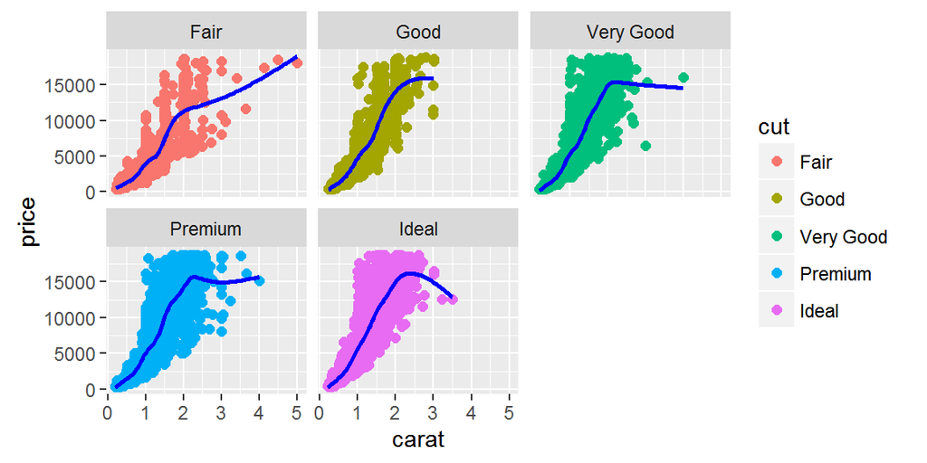

```r
diamonds %>%
  ggplot(aes(x=carat,y = price, color = cut)) +
  geom_point(size = 2) +
  facet_wrap( ~ cut) +
  geom_smooth(se = FALSE, color = "blue")
```